# TÜİK Forecasting Project – Motor Land Vehicles Statistics

# 9 Final Next-Period Forecast

```r
superior_method <- "Regression with Trend and Seasonal Dummy Variables"
final_fc        <- reg_fc
final_mape      <- round(mape_vals["Regression (Trend + Seasonal)"], 3)

cat("══════════════════════════════════════════════════════\n")
```

```
## ══════════════════════════════════════════════════════
```

```r
cat("FINAL FORECAST RESULT\n")
```

```
## FINAL FORECAST RESULT
```

```r
cat("══════════════════════════════════════════════════════\n")
```

```
## ══════════════════════════════════════════════════════
```

```r
cat("Superior method   :", superior_method,             "\n")
```

```
## Superior method   : Regression with Trend and Seasonal Dummy Variables
```

```r
cat("Data access date  :", format(DATA_ACCESS_DATE),    "\n")
```

```
## Data access date  : 2026-06-03
```

```r
cat("Latest observation:", format(latest_obs, "%Y-%m"), "\n")
```

```
## Latest observation: 2026-04
```

```r
cat("Forecast period   :", format(forecast_date,"%Y-%m"),"\n")
```

```
## Forecast period   : 2026-05
```

```r
cat("Forecasted value  :", format(round(final_fc), big.mark=","), "vehicles\n")
```

```
## Forecasted value  : 163,930 vehicles
```

```r
cat("Method MAPE       :", final_mape, "%\n")
```

```
## Method MAPE       : 30.867 %
```

```r
cat("══════════════════════════════════════════════════════\n")
```

```
## ══════════════════════════════════════════════════════
```

```r
final_df <- data.frame(
  Superior_Method         = superior_method,
  Data_Access_Date        = format(DATA_ACCESS_DATE),
  Latest_Observation      = format(latest_obs, "%Y-%m"),
  Forecast_Target_Period  = format(forecast_date, "%Y-%m"),
  Forecasted_Value        = round(final_fc),
  MAPE_pct                = final_mape
)
write.csv(final_df, "outputs/tables/final_forecast.csv", row.names=FALSE)
cat("Saved: outputs/tables/final_forecast.csv\n")
```

```
## Saved: outputs/tables/final_forecast.csv
```

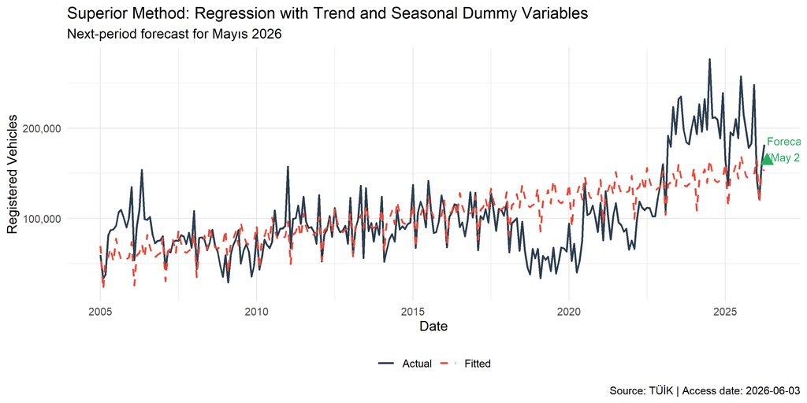

Superior Method – Final Forecast

```r
df_sup <- data.frame(date=date_vec, Actual=actual_vec, Fitted=reg_fitted) %>%
  pivot_longer(-date, names_to="series", values_to="value")

ggplot(df_sup, aes(x=date, y=value, colour=series, linetype=series)) +
  geom_line(na.rm=TRUE, linewidth=0.8) +
  annotate("point", x=forecast_date, y=final_fc, colour="#27AE60", size=4, shape=17) +
  annotate("text", x=forecast_date, y=final_fc*1.08,
           label=paste0("Forecast\n(", format(forecast_date,"%b %Y"), "): ",
                         format(round(final_fc), big.mark=",")),
           size=3.5, colour="#27AE60", hjust=0) +
  scale_colour_manual(values=c("Actual"="#2C3E50","Fitted"="#E74C3C")) +
  scale_linetype_manual(values=c("Actual"="solid","Fitted"="dashed")) +
  scale_y_continuous(labels=comma) +
  labs(title=paste("Superior Method:", superior_method),
       subtitle=paste("Next-period forecast for", format(forecast_date,"%B %Y")),
       x="Date", y="Registered Vehicles", colour=NULL, linetype=NULL,
       caption=paste("Source: TÜİK | Access date:", DATA_ACCESS_DATE)) +
  theme_minimal(base_size=12) + theme(legend.position="bottom")
```

```r
ggsave("outputs/figures/superior_method_plot.png", width=10, height=5, dpi=150)
```

# 10 Interpretation of Results

The regression model forecasts approximately **163,930** total motor land vehicle registrations for **Mayıs 2026** in Turkey.

This figure reflects the long-run upward trend in vehicle ownership combined with the seasonal pattern specific to the forecast month. Months with historically high registrations (positive seasonal dummy) will yield forecasts above the pure trend line, and vice versa.

# 11 Limitations

1. **Structural breaks**: Tax incentives, import quotas, or exchange rate shocks can shift registration patterns abruptly.
2. **COVID-19**: 2020 distortions inflate error measures and may distort seasonal indices.
3. **High volatility**: Point forecasts carry inherent uncertainty.
4. **No external predictors**: GDP, interest rates, consumer confidence not included.
5. **Data revisions**: TÜİK may revise previously published figures.

# 12 Reproducibility